# 30-Day Mortality Rate of Myocardia Infarction Patients Admitted to CCU and Discharged

Haoke Lian

2020/3/12

# Task

In this assignment, you are to write a report analyzing the electronic health record (EHR) data MIMIC-III. You report will demostrate your knowledge of working with PostgreSQL database, data visualization, and commonly used analytical methods such as logistic regression and neural network. Your report should include at least following parts:

1. An informative title. For example, *30-Day Mortality Rate of Myocardia Infarction Patients Admitted to CCU*.
2. Introduction. Describe the MIMIC-III data set and what research hypothesis/goal you are to address using this data.
3. Data preparation. Create a study cohort from MIMIC-III corresponding to your research hypothesis/goal. See the examplary code below. Use a CONSORT flow diagram to summarize your steps to create the cohort.
4. Data visualization. Use visualization to summarize the cohort you created.
5. Analytics. Use at least two analytical approaches to address your research hypothesis/goal. For example, we can use (1) logistic regression and (2) neural network to build a predictive model for the 30-day mortality rate of patients admitted into CCU and compare their predictive performance. Summarize your results in graphs.
6. Conclusions.

# Introduction

This project is a data analysis of the correlation of “30-day mortality rate of myocardia infarction patients admitted to CCU(Coronary Care Unit) and discharged from hospital” with patients’ features, hospital stays and chartevents. The patients’ data is based on MIMIC-III (Medical Information Mart for Intensive Care III), a large, freely-available database comprising deidentified health-related data associated with over forty thousand patients who stayed in critical care units of the Beth Israel Deaconess Medical Center between 2001 and 2012. The database includes information such as demographics, vital sign measurements made at the bedside (~1 data point per hour), laboratory test results, procedures, medications, caregiver notes, imaging reports, and mortality (both in and out of hospital). Specificly, for this research, age and gender of patients, insurance type, drug severity information, long title of disease, whether myocardia infraction is the principle disease or not, length of ICU stay are discussed to simulate the possible 30-day mortality rate of a myocardia infraction patient with certain features.

# Data preparation

## Tidy data

Load database, tidy data and data visualization libraries and the tidyverse frontend:

```r
# library(aod)
library(DBI)
library(RPostgreSQL)
library(tidyverse)
library(lubridate)
```

```r
library(dplyr)
library(ggplot2)
library(shape)
library(diagram)
library(keras)
library(tensorflow)
```

Credentials for using PostgreSQL database.

```r
# Load configuration settings
dbdriver <- 'PostgreSQL'
user  <- 'postgres'
password <- 'postgres'
dbname <- 'mimic'
schema <- 'mimiciii'
# Connect to the database using the configuration settings
con <- dbConnect(RPostgreSQL::PostgreSQL(),
                 dbname = dbname,
                 user = user,
                 password = password)
# Set the default schema
dbExecute(con, paste("SET search_path TO ", schema, sep=" "))
```

```
## [1] 0
```

```r
con
```

```
## <PostgreSQLConnection>
```

First, create a (query) table of patients who were directly admitted into CCU and their hosipital admissions.

```r
tbl(con, "transfers") %>%
  select(subject_id, hadm_id, prev_careunit, curr_careunit) %>%
  filter(is.na(prev_careunit) & curr_careunit == "CCU") %>%
  select(subject_id, hadm_id) %>%
  distinct() %>%
  print() -> ccu_admissions
```

```
## # Source:   lazy query [?? x 2]
## # Database: postgres 11.0.7 [postgres@/var/run/postgresql:5432/mimic]
##    subject_id hadm_id
##         <int>   <int>
##  1      42525  142743
##  2      23028  190183
##  3      24357  111518
##  4      23872  120477
##  5       9768  128541
##  6      23474  128369
##  7      30292  113876
##  8      19848  167716
##  9      12138  131429
## 10      10616  122738
## # … with more rows
```

Next, find all possible ICD-9 codes related to myocardial infarction, by searching for string `myocardial infarction` in the `long_title` of table `d_icd_diagnoses`. Then filter admissions of myocardial infarction patients by icd9_code.

```r
tbl(con, "d_icd_diagnoses") %>%
  filter(str_detect(tolower(long_title), "myocardial infarction")) %>%
  print() -> mi_codes
```

```
## # Source:   lazy query [?? x 4]
## # Database: postgres 11.0.7 [postgres@/var/run/postgresql:5432/mimic]
##    row_id icd9_code short_title        long_title
##     <int> <chr>     <chr>              <chr>
##  1   4335 41000     AMI anterolateral… Acute myocardial infarction of anterolat…
##  2   4336 41001     AMI anterolateral… Acute myocardial infarction of anterolat…
##  3   4337 41002     AMI anterolateral… Acute myocardial infarction of anterolat…
##  4   4338 41010     AMI anterior wall… Acute myocardial infarction of other ant…
##  5   4339 41011     AMI anterior wall… Acute myocardial infarction of other ant…
##  6   4340 41012     AMI anterior wall… Acute myocardial infarction of other ant…
##  7   4341 41020     AMI inferolateral… Acute myocardial infarction of inferolat…
##  8   4342 41021     AMI inferolateral… Acute myocardial infarction of inferolat…
##  9   4343 41022     AMI inferolateral… Acute myocardial infarction of inferolat…
## 10   4344 41030     AMI inferopost, u… Acute myocardial infarction of inferopos…
## # … with more rows
```

```r
tbl(con, "diagnoses_icd") %>%
  right_join(mi_codes, by = "icd9_code") %>%
  print() -> mi_admissions
```

```
## # Source:   lazy query [?? x 8]
## # Database: postgres 11.0.7 [postgres@/var/run/postgresql:5432/mimic]
##    row_id.x subject_id hadm_id seq_num icd9_code row_id.y short_title long_title
##       <int>      <int>   <int>   <int> <chr>        <int> <chr>       <chr>
##  1   175785      15805  188616       1 41000         4335 AMI antero… Acute myo…
##  2   281839      25208  167918       7 41000         4335 AMI antero… Acute myo…
##  3      594         73  194730       1 41001         4336 AMI antero… Acute myo…
##  4     6395        543  115307       1 41001         4336 AMI antero… Acute myo…
##  5     6630        571  193189       1 41001         4336 AMI antero… Acute myo…
##  6    11015        947  122379       1 41001         4336 AMI antero… Acute myo…
##  7    12916       1114  164691       2 41001         4336 AMI antero… Acute myo…
##  8    14945       1317  198886       1 41001         4336 AMI antero… Acute myo…
##  9    18340       1626  117062       1 41001         4336 AMI antero… Acute myo…
## 10    30343       2700  100335       1 41001         4336 AMI antero… Acute myo…
## # … with more rows
```

In order to focus on patients for whom MI was central to their hospitalization, admissions of patients with MI as any of the 5 most important diagnosis positions areincluded, according to the `seq_num` field.`group_by()` and `filter()` are used to limit the query to the first MI diagnosis for each admission to avoid duplicate admissions.

```r
mi_admissions %>%
  filter(seq_num <= 5) %>%
  group_by(subject_id, hadm_id) %>%
  filter(min_rank(seq_num) <= 1) %>%
  ungroup() %>%
  select(subject_id, hadm_id, long_title, seq_num) %>%
  print() -> mi_admissions
```

```
## # Source:   lazy query [?? x 4]
## # Database: postgres 11.0.7 [postgres@/var/run/postgresql:5432/mimic]
##    subject_id hadm_id long_title                                         seq_num
##         <int>   <int> <chr>                                                <int>
##  1         24  161859 Acute myocardial infarction of other inferior wal…       1
##  2         28  162569 Old myocardial infarction                                4
##  3         42  119203 Old myocardial infarction                                4
##  4         53  155385 Acute myocardial infarction of inferolateral wall…       1
##  5         73  194730 Acute myocardial infarction of anterolateral wall…       1
##  6         79  181542 Acute myocardial infarction of other anterior wal…       1
##  7        108  123552 Old myocardial infarction                                5
##  8        111  192123 Acute myocardial infarction of other specified si…       5
##  9        123  195632 Acute myocardial infarction of other anterior wal…       1
## 10        149  154869 Acute myocardial infarction of other anterior wal…       1
## # … with more rows
```

`inner_join` the table of admissions to CCU and the table of admissions that include MI diagnosis as top 5 diagnosis, to the table of MI patients and admissions, i.e. the target of study.

```r
ccu_admissions %>%
  inner_join(mi_admissions, by = c("subject_id", "hadm_id")) %>%
  print() -> study_admissions
```

```
## # Source:   lazy query [?? x 4]
## # Database: postgres 11.0.7 [postgres@/var/run/postgresql:5432/mimic]
##    subject_id hadm_id long_title                                         seq_num
##         <int>   <int> <chr>                                                <int>
##  1         24  161859 Acute myocardial infarction of other inferior wal…       1
##  2         42  119203 Old myocardial infarction                                4
##  3         53  155385 Acute myocardial infarction of inferolateral wall…       1
##  4         73  194730 Acute myocardial infarction of anterolateral wall…       1
##  5        111  192123 Acute myocardial infarction of other specified si…       5
##  6        123  195632 Acute myocardial infarction of other anterior wal…       1
##  7        149  154869 Acute myocardial infarction of other anterior wal…       1
##  8        154  111735 Acute myocardial infarction of other inferior wal…       1
##  9        158  169433 Old myocardial infarction                                4
## 10        160  161672 Acute myocardial infarction of other inferior wal…       1
## # … with more rows
```

Create a logical variable indicating whether MI is the principal diagonosis or not.

```r
study_admissions %>%
  mutate(principal_dx = seq_num == 1) %>%
  select(-seq_num) %>%
  print() -> study_admissions
```

```
## # Source:   lazy query [?? x 4]
## # Database: postgres 11.0.7 [postgres@/var/run/postgresql:5432/mimic]
##    subject_id hadm_id long_title                                    principal_dx
##         <int>   <int> <chr>                                         <lgl>
##  1         24  161859 Acute myocardial infarction of other inferio… TRUE
##  2         42  119203 Old myocardial infarction                     FALSE
##  3         53  155385 Acute myocardial infarction of inferolateral… TRUE
##  4         73  194730 Acute myocardial infarction of anterolateral… TRUE
##  5        111  192123 Acute myocardial infarction of other specifi… FALSE
##  6        123  195632 Acute myocardial infarction of other anterio… TRUE
##  7        149  154869 Acute myocardial infarction of other anterio… TRUE
##  8        154  111735 Acute myocardial infarction of other inferio… TRUE
##  9        158  169433 Old myocardial infarction                     FALSE
## 10        160  161672 Acute myocardial infarction of other inferio… TRUE
## # … with more rows
```

Add the severity of patients’ ailments by count the number of APR(All Payers Registry) included in the `DRG` codes in `drgcodes` table and pull the drug severity information and right-join it to our query table.

```r
tbl(con, "drgcodes") %>%
  filter(str_detect(drg_type, "APR")) %>%
  select(subject_id, hadm_id, drg_severity) %>%
  right_join(study_admissions, by = c("subject_id", "hadm_id")) %>%
  mutate(drg_severity = ifelse(is.na(drg_severity), 1, drg_severity)) %>%
  print() -> study_admissions
```

```
## # Source:   lazy query [?? x 5]
## # Database: postgres 11.0.7 [postgres@/var/run/postgresql:5432/mimic]
##    subject_id hadm_id drg_severity long_title                       principal_dx
##         <int>   <int>        <dbl> <chr>                            <lgl>
##  1         24  161859            1 Acute myocardial infarction of … TRUE
##  2         42  119203            1 Old myocardial infarction        FALSE
##  3         53  155385            1 Acute myocardial infarction of … TRUE
##  4         73  194730            1 Acute myocardial infarction of … TRUE
##  5        111  192123            4 Acute myocardial infarction of … FALSE
##  6        123  195632            1 Acute myocardial infarction of … TRUE
##  7        149  154869            1 Acute myocardial infarction of … TRUE
##  8        154  111735            1 Acute myocardial infarction of … TRUE
##  9        158  169433            1 Old myocardial infarction        FALSE
## 10        160  161672            1 Acute myocardial infarction of … TRUE
## # … with more rows
```

Include the admission time `admittime`, discharge time `dischtime`, date of birth `dob`, and date of death `dod` of patients discharged from hospital.

```r
study_admissions %>%
  left_join(
    select(tbl(con, "admissions"),
           subject_id, hadm_id, admittime, dischtime, hospital_expire_flag
    ), by = c("subject_id", "hadm_id")
  ) %>%
  filter(hospital_expire_flag == 0) %>%
  select(-hospital_expire_flag) %>%
  left_join(
    select(tbl(con, "patients"), subject_id, dob, dod),
    by = "subject_id"
  ) %>%
  print(width = Inf) -> study_admissions
```

```
## # Source:   lazy query [?? x 9]
## # Database: postgres 11.0.7 [postgres@/var/run/postgresql:5432/mimic]
##    subject_id hadm_id drg_severity
##         <int>   <int>        <dbl>
##  1         24  161859            1
##  2         42  119203            1
##  3         53  155385            1
##  4         73  194730            1
##  5        111  192123            4
##  6        123  195632            1
##  7        149  154869            1
##  8        154  111735            1
##  9        158  169433            1
## 10        160  161672            1
##    long_title
```

[output cut: 36 more lines]

Add 30-day mortality rate as a logical viriable, `age` (at admission) variable into the table, and remove patients of 90 years and older, for their ages are artificially inflated.

```r
study_admissions %>%
  mutate(tt_death = date_part("day", dod) - date_part("day", dischtime)) %>%
  mutate(mortality = tt_death <= 30) %>%
  mutate(age = date_part("year", admittime) - date_part("year", dob)) %>%
  filter(age < 90) %>%
  mutate(age = age - ifelse(
    date_part("month", admittime) < date_part("month", dob) |
      (
        date_part("month", admittime) == date_part("month", dob) &
          date_part("day", admittime) < date_part("day", dob)
      ),
    1,
    0
  )) %>%
  select(-admittime, -dischtime, -dob, -dod, -tt_death) %>%
  select(subject_id, hadm_id, age, mortality, everything()) %>%
  print() -> study_admissions
```

```
## # Source:   lazy query [?? x 7]
## # Database: postgres 11.0.7 [postgres@/var/run/postgresql:5432/mimic]
##    subject_id hadm_id   age mortality drg_severity long_title       principal_dx
##         <int>   <int> <dbl> <lgl>            <dbl> <chr>            <lgl>
##  1         24  161859    39 NA                   1 Acute myocardia… TRUE
##  2         42  119203    61 TRUE                 1 Old myocardial … FALSE
##  3         53  155385    45 NA                   1 Acute myocardia… TRUE
##  4         73  194730    57 NA                   1 Acute myocardia… TRUE
##  5        111  192123    66 TRUE                 4 Acute myocardia… FALSE
##  6        123  195632    56 NA                   1 Acute myocardia… TRUE
##  7        154  111735    44 NA                   1 Acute myocardia… TRUE
##  8        158  169433    67 NA                   1 Old myocardial … FALSE
##  9        160  161672    49 NA                   1 Acute myocardia… TRUE
## 10        194  124794    47 NA                   1 Acute myocardia… TRUE
## # … with more rows
```

Merge patients’ information (insurance, gender) into target of study `study_admissions`.

```r
tbl(con, "admissions") %>%
  select(subject_id, insurance) %>%
  distinct() %>%
  print() -> study_subjects
```

```
## # Source:   lazy query [?? x 2]
## # Database: postgres 11.0.7 [postgres@/var/run/postgresql:5432/mimic]
##    subject_id insurance
##         <int> <chr>
##  1      53626 Medicare
##  2      23134 Private
##  3      21814 Private
##  4      15180 Private
##  5      89329 Medicaid
##  6      25659 Medicare
##  7      32304 Private
##  8      25813 Private
##  9      88291 Medicare
## 10       3522 Medicare
## # … with more rows
```

```r
tbl(con, "patients") %>%
  select(subject_id, gender) %>%
  distinct() %>%
  full_join(study_subjects, by = "subject_id") %>%
  print() -> study_subjects
```

```
## # Source:   lazy query [?? x 3]
## # Database: postgres 11.0.7 [postgres@/var/run/postgresql:5432/mimic]
##    subject_id gender insurance
##         <int> <chr>  <chr>
##  1      26121 M      Medicare
##  2       7489 F      Private
##  3      81661 M      Medicare
##  4      30273 F      Medicare
##  5      55935 F      Medicare
##  6      63914 M      Medicaid
##  7      19393 M      Private
##  8      15861 M      Private
##  9      12289 F      Medicare
## 10      31927 F      Medicaid
## # … with more rows
```

```r
study_admissions %>%
  left_join(study_subjects, by = "subject_id", copy = TRUE) %>%
  print() -> study_admissions
```

```
## # Source:   lazy query [?? x 9]
## # Database: postgres 11.0.7 [postgres@/var/run/postgresql:5432/mimic]
##    subject_id hadm_id   age mortality drg_severity long_title principal_dx
##         <int>   <int> <dbl> <lgl>            <dbl> <chr>      <lgl>
##  1      11418  172277    49 NA                   1 Old myoca… FALSE
##  2      11787  156196    70 TRUE                 1 Acute myo… TRUE
##  3      28951  162713    61 NA                   3 Acute myo… TRUE
##  4      28951  162713    61 NA                   3 Acute myo… TRUE
##  5      24780  112905    50 NA                   2 Acute myo… TRUE
##  6      30647  179424    59 NA                   2 Acute myo… TRUE
##  7      30647  179424    59 NA                   2 Acute myo… TRUE
##  8       5960  159343    87 TRUE                 1 Acute myo… TRUE
##  9      23893  171761    83 NA                   1 Old myoca… FALSE
## 10      81371  130123    64 NA                   2 Acute myo… TRUE
## # … with more rows, and 2 more variables: gender <chr>, insurance <chr>
```

Merge length of ICU stays into target of study `study_admissions`.

```r
study_admissions %>%
  left_join(
    select(tbl(con, "icustays"),
           subject_id, hadm_id, los), by = c("subject_id", "hadm_id")
  ) %>%
  group_by(subject_id, hadm_id) %>%
  filter(row_number() == 1) %>%
  ungroup() %>%
  print() -> study_admissions
```

```
## # Source:   lazy query [?? x 10]
## # Database: postgres 11.0.7 [postgres@/var/run/postgresql:5432/mimic]
##    subject_id hadm_id   age mortality drg_severity long_title principal_dx
##         <int>   <int> <dbl> <lgl>            <dbl> <chr>      <lgl>
##  1         24  161859    39 NA                   1 Acute myo… TRUE
##  2         42  119203    61 TRUE                 1 Old myoca… FALSE
##  3         53  155385    45 NA                   1 Acute myo… TRUE
##  4         73  194730    57 NA                   1 Acute myo… TRUE
##  5        111  192123    66 TRUE                 4 Acute myo… FALSE
##  6        123  195632    56 NA                   1 Acute myo… TRUE
##  7        154  111735    44 NA                   1 Acute myo… TRUE
##  8        158  169433    67 NA                   1 Old myoca… FALSE
##  9        160  161672    49 NA                   1 Acute myo… TRUE
## 10        194  124794    47 NA                   1 Acute myo… TRUE
## # … with more rows, and 3 more variables: gender <chr>, insurance <chr>,
## #   los <dbl>
```

```r
study_admissions = collect(study_admissions)
study_admissions[, 4][is.na(study_admissions[, 4])] = 0
study_admissions$mortality = as.logical(study_admissions$mortality)
```

Close the connection:

```r
dbDisconnect(con)
```

```
## [1] TRUE
```

## CONSORT Flow Diagrams

CONSORT Flow Diagrams can be used to plot the flow of data selection of a patient cohort.

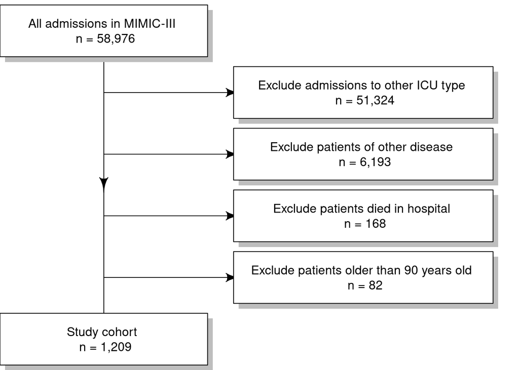

```r
# set margins and multiplot
par(mfrow = c(1, 1))
par(mar = c(0, 0, 0, 0))

# initialise a plot device
openplotmat()

# position of boxes
# 1st column indicates x axis position between 0 and 1
# 2nd column indicates y axis position between 0 and 1
# automatically assigns vertical position
num_of_boxes <- 6
auto_coords = coordinates(num_of_boxes)
vert_pos = rev(auto_coords[,1])
box_pos <- matrix(nrow = num_of_boxes, ncol = 2, data = 0)
box_pos[1,] = c(0.20, vert_pos[1]) # 1st box
box_pos[2,] = c(0.70, vert_pos[2]) # 2nd box
box_pos[3,] = c(0.70, vert_pos[3]) # 3rd box
box_pos[4,] = c(0.70, vert_pos[4])
box_pos[5,] = c(0.70, vert_pos[5])
box_pos[6,] = c(0.20, vert_pos[6])

# content of boxes
box_content <- matrix(nrow = num_of_boxes, ncol = 1, data = 0)
box_content[1] = "All admissions in MIMIC-III \n n = 58,976" # 1st box
box_content[2] = "Exclude admissions to other ICU type \n n = 51,324" # 2nd box
box_content[3] = "Exclude patients of other disease \n n = 6,193" # 3rd box
box_content[4] = "Exclude patients died in hospital \n n = 168"
box_content[5] = "Exclude patients older than 90 years old \n n = 82"
box_content[6] = "Study cohort \n n = 1,209"

# adjust the size of boxes to fit content
box_x <- c(0.20, 0.25, 0.25, 0.25, 0.25, 0.20)
box_y <- c(0.07, 0.07, 0.07, 0.07, 0.07, 0.07)

# Draw the arrows
straightarrow(from = c(box_pos[1,1],box_pos[2,2]), to = box_pos[2,], lwd = 1)
straightarrow(from = c(box_pos[1,1],box_pos[3,2]), to = box_pos[3,], lwd = 1)
straightarrow(from = c(box_pos[1,1],box_pos[4,2]), to = box_pos[4,], lwd = 1)
straightarrow(from = c(box_pos[1,1],box_pos[5,2]), to = box_pos[5,], lwd = 1)
straightarrow(from = box_pos[1,], to = box_pos[6,], lwd = 1)

# Draw the boxes
for (i in 1:num_of_boxes) {
  textrect(mid = box_pos[i,], radx = box_x[i], rady = box_y[i],
           lab = box_content[i],
           shadow.col = "grey")
  }
```

# Data Visualization

In this part, the correlation between a certain feature of patients and the 30-day mortality rate will be displayed, based on MIMIC-III data.

## Age of Patients

Display how the mortality rate affected by age of patients.

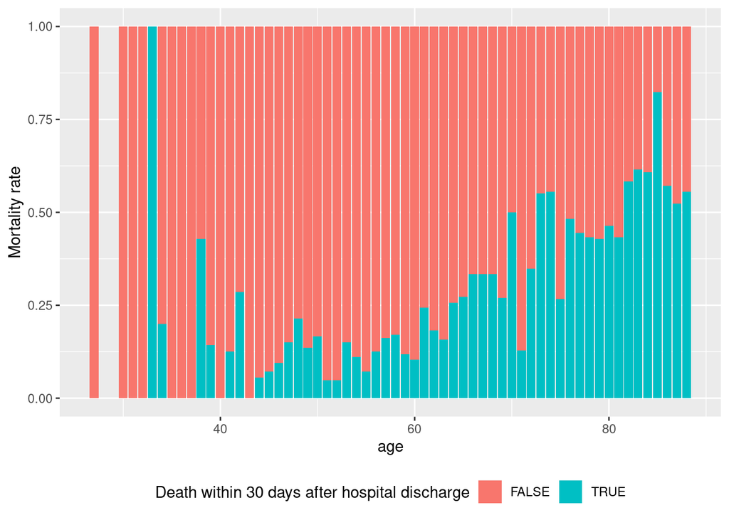

```r
ggplot(data = study_admissions) +
  geom_bar(mapping = aes(x = age, fill = mortality), position = "fill") +
  theme(legend.position="bottom") +
  scale_fill_discrete(name="Death within 30 days after hospital discharge") +
  labs(y = "Mortality rate")
```

## Gender of Patients

Display how the mortality rate affected by gender of patients.

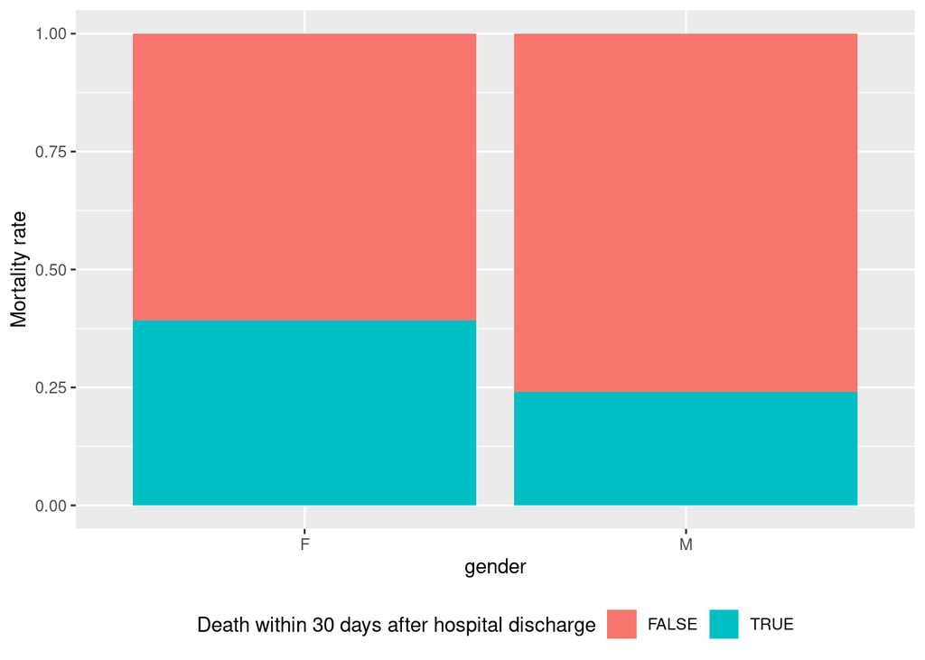

```r
ggplot(data = study_admissions) +
  geom_bar(mapping = aes(x = gender, fill = mortality), position = "fill") +
  theme(legend.position="bottom") +
  scale_fill_discrete(name="Death within 30 days after hospital discharge") +
  labs(y = "Mortality rate")
```

## Insurance type of patients

Display how the mortality rate affected by insurance type of patients.

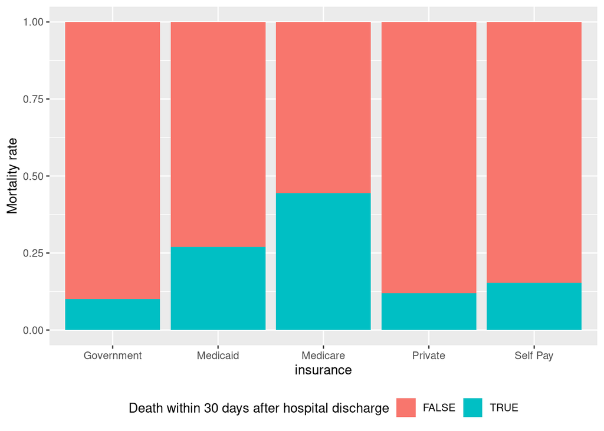

```r
ggplot(data = study_admissions) +
  geom_bar(mapping = aes(x = insurance, fill = mortality), position = "fill") +
  theme(legend.position="bottom") +
  scale_fill_discrete(name="Death within 30 days after hospital discharge") +
  labs(y = "Mortality rate")
```

## Drug severity information of patients

Display how the mortality rate affected by drug severity information of Patients.

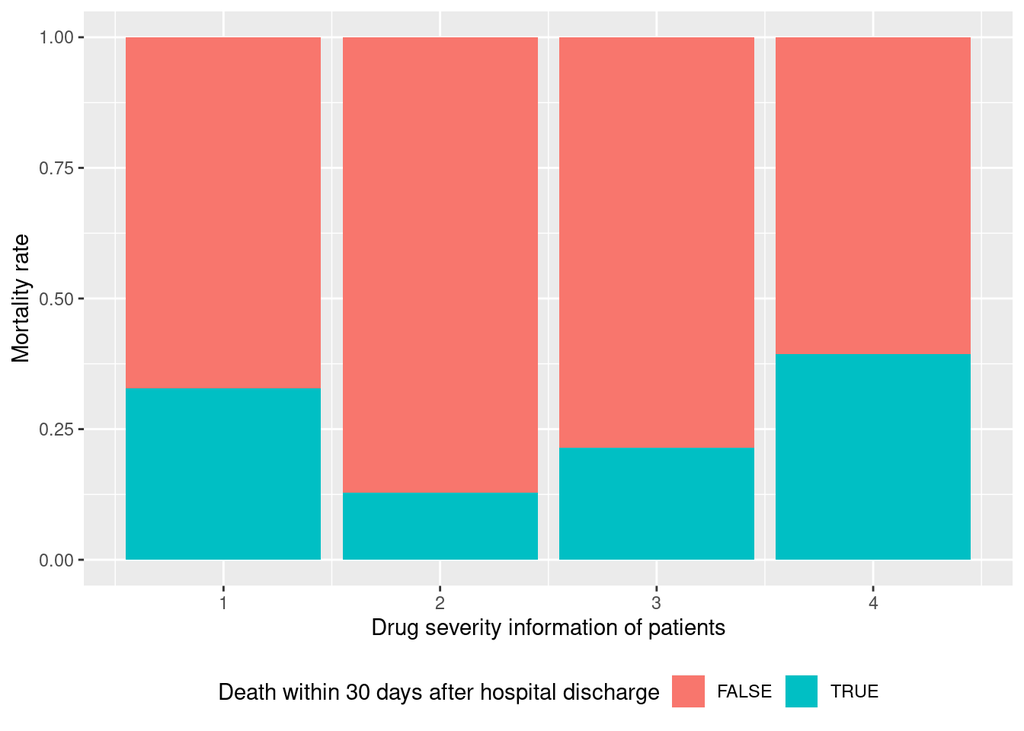

```r
ggplot(data = study_admissions) +
  geom_bar(mapping = aes(x = drg_severity, fill = mortality), position = "fill") +
  theme(legend.position="bottom") +
  scale_fill_discrete(name="Death within 30 days after hospital discharge") +
  labs(y = "Mortality rate") +
  labs(x = "Drug severity information of patients")
```

## Long title of patient’s disease

Display the portion of each disease in died patients.

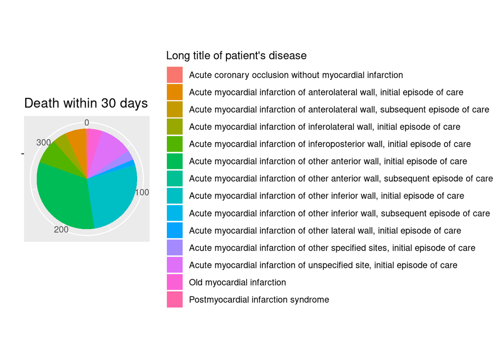

```r
study_admissions %>%
  filter(mortality == TRUE) %>%
  ggplot(mapping = aes(x = "",
                       fill = long_title)) +
  geom_bar(width = 1) +
  coord_polar("y") +
  # theme(legend.position="bottom") +
  scale_fill_discrete(name="Long title of patient's disease") +
  labs(x = "", y = "", title = "Death within 30 days")
```

## Myocardia infraction is the principle disease or not

Display how the mortality rate affected by whether myocardia infraction is the principle disease or not.

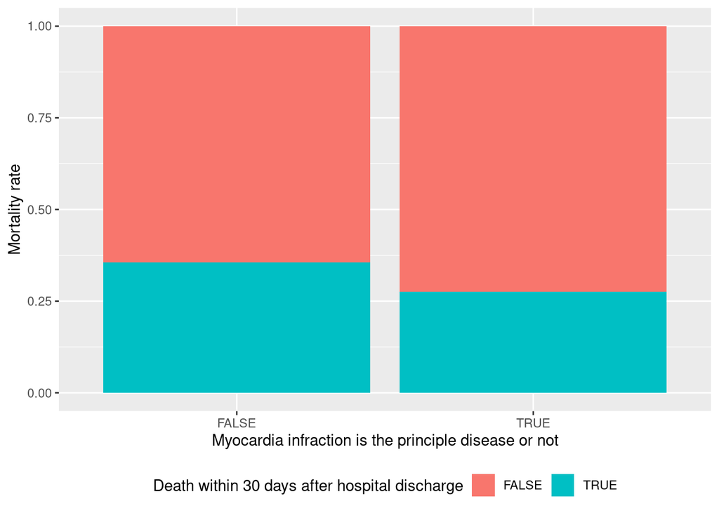

```r
ggplot(data = study_admissions) +
  geom_bar(mapping = aes(x = principal_dx, fill = mortality), position = "fill") +
  theme(legend.position="bottom") +
  scale_fill_discrete(name="Death within 30 days after hospital discharge") +
  labs(y = "Mortality rate") +
  labs(x = "Myocardia infraction is the principle disease or not")
```

## Length of ICU stay

Display the correlation between length of ICU stay and number of death within 30 days after hosipital discharge.

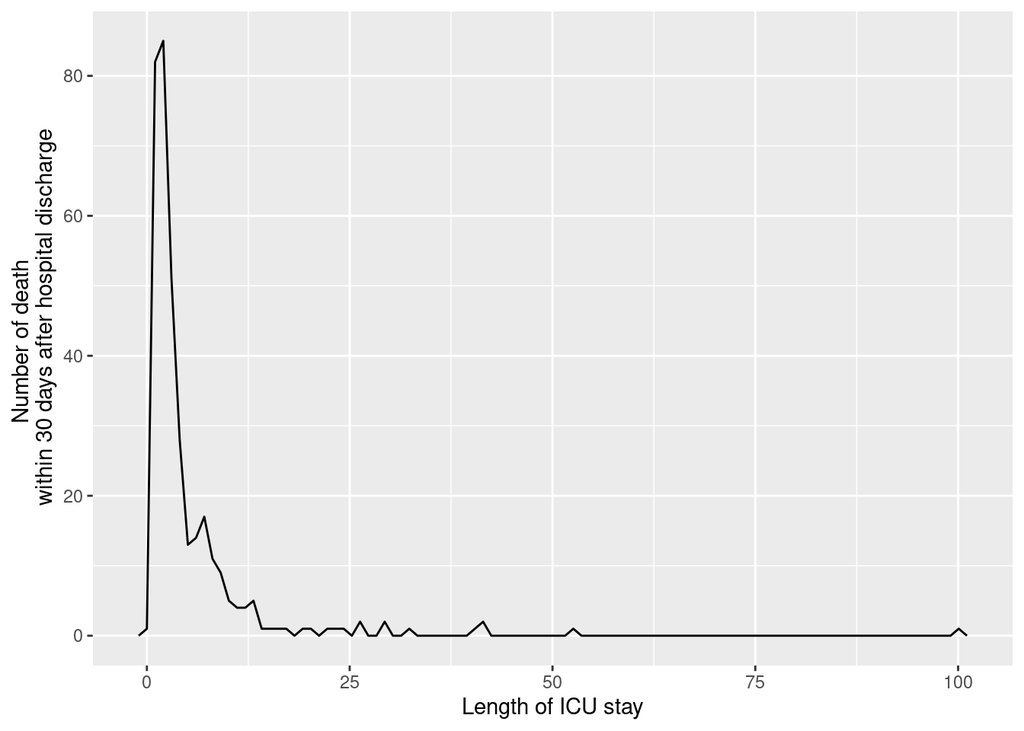

```r
study_admissions %>%
  filter(mortality == TRUE) %>%
  ggplot(aes(x = los)) +
  geom_freqpoly(bins = 100) +
  labs(x = "Length of ICU stay", y = "Number of death
       within 30 days after hospital discharge")
```

# Analytics

According to the visualiztion of data, durg serverity information and age of patients and the length of ICU stay are selected as main factors of 30-day motality rate after hospital discharge because of the large difference between 30-day mortality rates of different durg serverities, length of ICU stays and ages.

## Logistic Regression Using the Generalized Linear Model Function

### Generate description for variables

This dataset has a binary response (outcome, dependent) variable mortality. There are three predictor variables: age, lenth of ICU stay and drug severity. Treat the variables age, lenth of ICU stay as continuous. The variable drug severity takes on the values 1 through 4. Get basic descriptives for the entire data set by using summary.

```r
study_admissions$mortality = as.integer(study_admissions$mortality)
study_admissions_ = study_admissions
study_admissions_$drg_severity <- factor(study_admissions_$drg_severity)
study_logit <- glm(mortality ~ age + drg_severity + los,
                   data = study_admissions_,
                   family = "binomial")
(summary(study_logit))
```

```
##
## Call:
## glm(formula = mortality ~ age + drg_severity + los, family = "binomial",
##     data = study_admissions_)
##
## Deviance Residuals:
##     Min       1Q   Median       3Q      Max
## -2.1213  -0.7975  -0.4902   0.9432   2.9507
##
## Coefficients:
##                Estimate Std. Error z value Pr(>|z|)
## (Intercept)   -5.460627   0.425840 -12.823  < 2e-16 ***
## age            0.069232   0.006156  11.246  < 2e-16 ***
## drg_severity2 -1.304231   0.249137  -5.235 1.65e-07 ***
## drg_severity3 -0.898132   0.212122  -4.234 2.30e-05 ***
## drg_severity4 -0.213613   0.215372  -0.992    0.321
## los            0.068736   0.016418   4.187 2.83e-05 ***
## ---
## Signif. codes:  0 '***' 0.001 '**' 0.01 '*' 0.05 '.' 0.1 ' ' 1
##
## (Dispersion parameter for binomial family taken to be 1)
##
##     Null deviance: 1451.3  on 1208  degrees of freedom
## Residual deviance: 1222.7  on 1203  degrees of freedom
## AIC: 1234.7
##
## Number of Fisher Scoring iterations: 5
```

### Obtain confidence intervals

Use the confint function to obtain confidence intervals for the coefficient estimates. Note that for logistic models, confidence intervals are based on the profiled log-likelihood function. Get CIs based on just the standard errors by using the default method.

```r
confint(study_logit)
```

```
##                     2.5 %      97.5 %
## (Intercept)   -6.31523415 -4.64470958
## age            0.05738631  0.08153657
## drg_severity2 -1.81266055 -0.83274080
## drg_severity3 -1.32379497 -0.49081345
## drg_severity4 -0.64120211  0.20430606
## los            0.03794833  0.10249961
```

### Predict 30-day mortality rate

```r
testdata1 <- with(study_admissions_, data.frame(age = rep(seq(from = 0,
                                                                    to = 100,
                                                            length.out = 100),4
                                                         ),
                                                 los = mean(los),
                                                 drg_severity = factor(rep(1:4,
                                                                    each = 100)
                                                            )
                                              ))
testdata2 <- cbind(testdata1, predict(study_logit,
                                      newdata = testdata1,
                                      type = "link",
    se = TRUE))
(testdata2 <- within(testdata2, {
    Predicted_Mortality <- plogis(fit)
    LL <- plogis(fit - (1.96 * se.fit))
    UL <- plogis(fit + (1.96 * se.fit))
}))
```

```
##            age      los drg_severity         fit     se.fit residual.scale
## 1     0.000000 3.412726            1 -5.22604928 0.42245062              1
## 2     1.010101 3.412726            1 -5.15611838 0.41637538              1
## 3     2.020202 3.412726            1 -5.08618749 0.41030444              1
## 4     3.030303 3.412726            1 -5.01625659 0.40423798              1
## 5     4.040404 3.412726            1 -4.94632569 0.39817620              1
## 6     5.050505 3.412726            1 -4.87639480 0.39211934              1
## 7     6.060606 3.412726            1 -4.80646390 0.38606762              1
## 8     7.070707 3.412726            1 -4.73653300 0.38002128              1
## 9     8.080808 3.412726            1 -4.66660210 0.37398059              1
## 10    9.090909 3.412726            1 -4.59667121 0.36794582              1
## 11   10.101010 3.412726            1 -4.52674031 0.36191726              1
## 12   11.111111 3.412726            1 -4.45680941 0.35589525              1
## 13   12.121212 3.412726            1 -4.38687851 0.34988011              1
## 14   13.131313 3.412726            1 -4.31694762 0.34387220              1
```

[output cut: 787 more lines]

Use graphs of predicted probabilities to understand present the model. Below is a plot with the predicted 30_day mortality rate verses age of patients, comparing different drug serverities, with 95% confidence intervals.

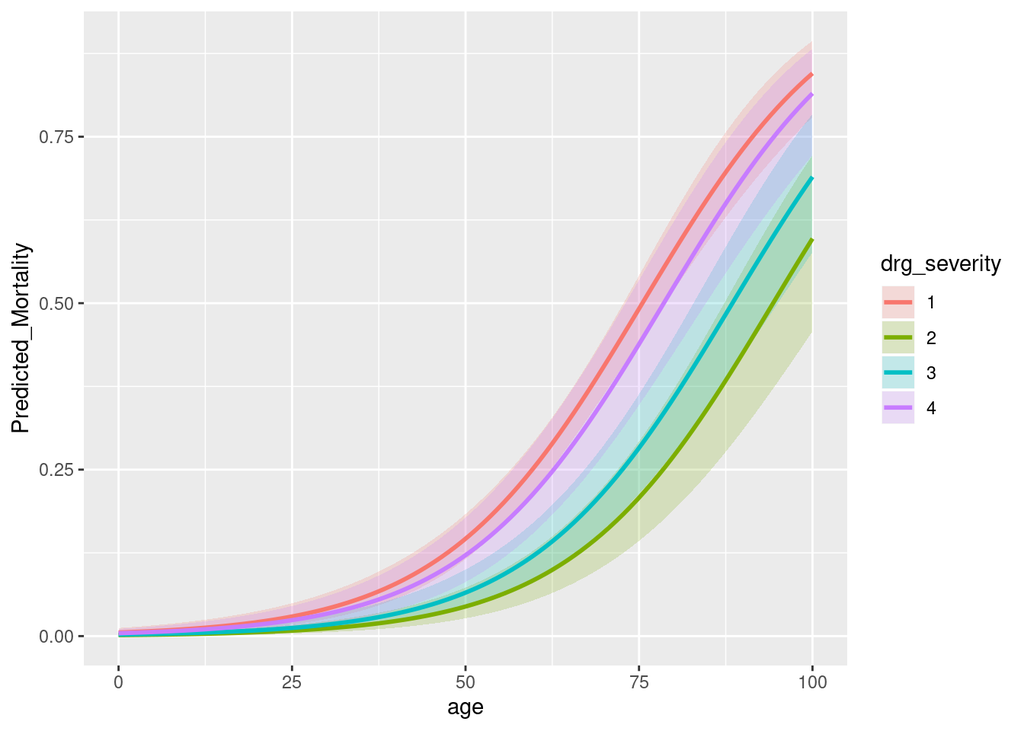

```r
ggplot(testdata2, aes(x = age, y = Predicted_Mortality)) +
  geom_ribbon(aes(ymin = LL, ymax = UL, fill = drg_severity), alpha = 0.2) +
  geom_line(aes(colour = drg_severity), size = 1)
```

## Neural Network with Multi-Layer Perceptron

### Prepare data

Aquire data and separate the data set to training and test data.

```r
study_admissions$mortality = as.integer(study_admissions$mortality)
x_matrix = as.matrix(select(study_admissions, age, los, drg_severity))
y_matrix = as.matrix(select(study_admissions, mortality))
x_train = x_matrix[2:1000, ]
x_test = x_matrix[1000:1209, ]
dim(x_train)
```

```
## [1] 999   3
```

```r
dim(x_test)
```

```
## [1] 210   3
```

```r
y_train = y_matrix[2:1000]
y_train <- array_reshape(y_train, c(999, 1))
y_test = y_matrix[1000:1209]
y_test <- array_reshape(y_test, c(210, 1))
dim(y_train)
```

```
## [1] 999   1
```

```r
dim(y_test)
```

```
## [1] 210   1
```

Encode y as binary class matrix:

```r
y_train <- to_categorical(y_train, 2)
y_test <- to_categorical(y_test, 2)
dim(y_train)
```

```
## [1] 999   2
```

```r
dim(y_test)
```

```
## [1] 210   2
```

### Define the model

Define a sequential model:

```r
model <- keras_model_sequential()
model %>%
  layer_dense(units = 3, activation = 'relu', input_shape = c(3)) %>%
  layer_dropout(rate = 0) %>%
  layer_dense(units = 2, activation = 'softmax', input_shape = c(3))
model %>% save_model_tf("model")
summary(model)
```

```
## Model: "sequential"
## ________________________________________________________________________________
## Layer (type)                        Output Shape                    Param #
## ================================================================================
## dense (Dense)                       (None, 3)                       12
## ________________________________________________________________________________
## dropout (Dropout)                   (None, 3)                       0
## ________________________________________________________________________________
## dense_1 (Dense)                     (None, 2)                       8
## ================================================================================
## Total params: 20
## Trainable params: 20
## Non-trainable params: 0
## ________________________________________________________________________________
```

### Compile the model

Compile the model with appropriate loss function, optimizer, and metrics:

```r
model %>% compile(
  loss = 'categorical_crossentropy',
  optimizer = optimizer_rmsprop(),
  metrics = c('accuracy')
)
```

### Training and validation

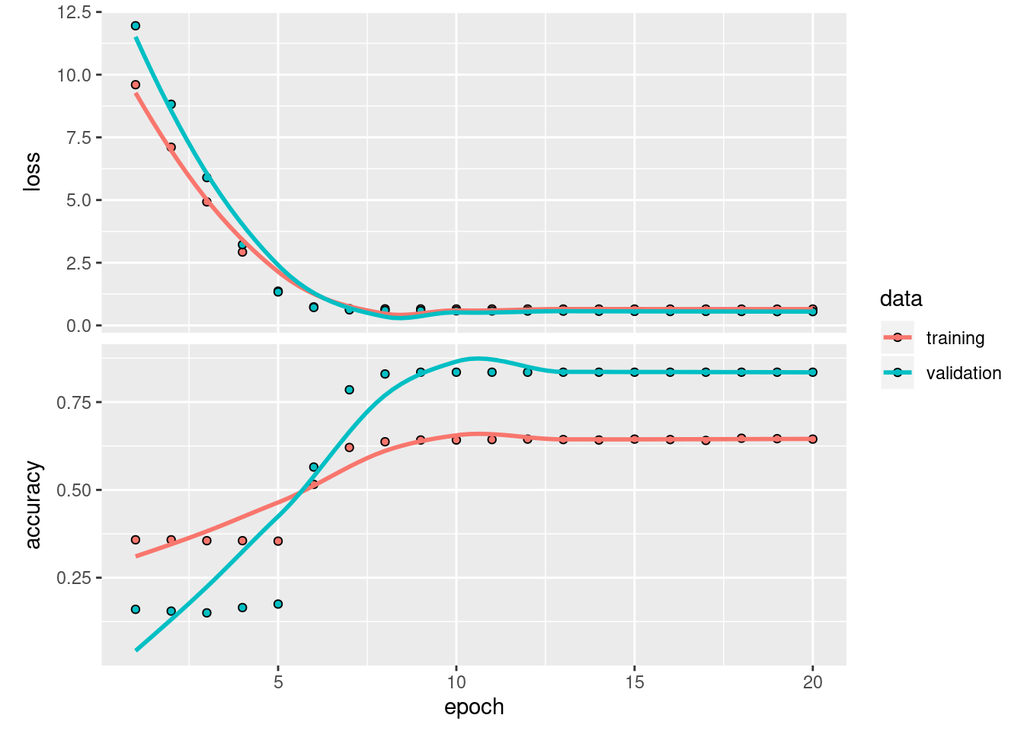

```r
history <- model %>% fit(
  x_train, y_train,
  epochs = 20, batch_size = NULL,
  validation_split = 0.2
)

plot(history)
```

### Evaluate model performance on the test data:

```r
model %>% evaluate(x_test, y_test)
```

```
## $loss
## [1] 0.539923
##
## $accuracy
## [1] 0.8523809
```

The loss of data is high. The possible reason is the epoch is higher than enough, so that the model is over-trained. However, after several tries to cut down the loss by decreasing the epoch, it ends up with higher data loss.

### Generate predictions on new data:

```r
model %>% predict_classes(x_test) %>% head()
```

```
## [1] 0 0 0 0 0 0
```

The prediction on the test data means that none of these patients will be died in 30 days after hospital discharge.